# STATS506 Problem Set #05

Author

Fan Zhang

Published

November 19, 2023

GitHub Repository: https://github.com/cajole-fff/UMich-STATS506-FanZhang/

## Problem 1 - Plotting

Use the `nnmaps` data set again. I’d recommend using `ggplot2` for these, but you can do them in base R or `plotly` if you’d prefer.

1. Produce a graph of the `mean` monthly temperature in celsius. Draw a scatter-plot where the $x$-axis is month and the $y$-axis is the average monthly temperature in celsius. Add a line connecting the points within each season and color the lines and points by season (same color for lines and points in the same season). Be sure both $x$-axis and the legend are ordered appropriately, and that all labels/titles are clear and ready for publication (e.g. no variable names).

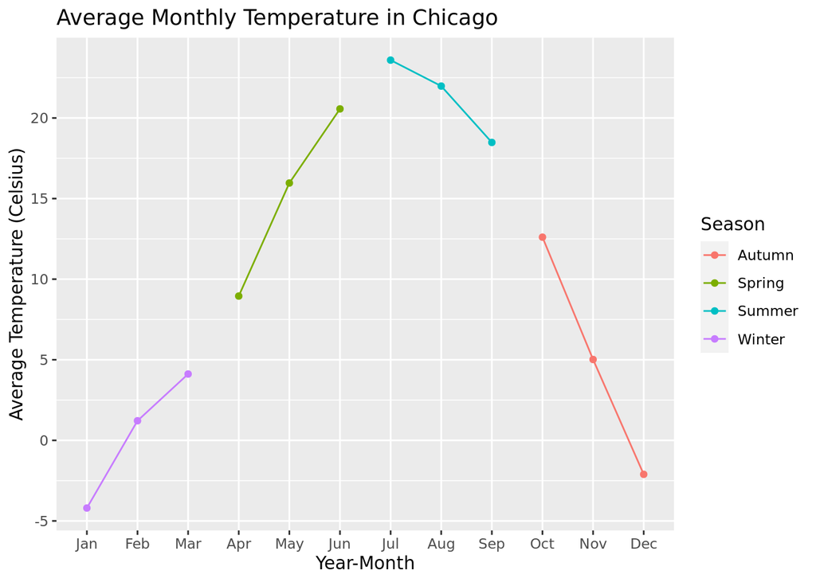

```r
# Load data
nnmaps <- read.csv("./data/chicago-nnmaps.csv")
# Convert temperature to celsius
nnmaps$tempC <- (nnmaps$temp - 32) * 5 / 9

# Plot monthly temperature in celsius (averaged over year)
library(ggplot2)
library(dplyr)
nnmaps$month <- factor(nnmaps$month, levels = month.abb)
nnmaps$year_month <- paste(nnmaps$year, nnmaps$month, sep = "-")

nnmaps_summary_temp <- nnmaps %>%
    mutate(
        date = as.POSIXct(date, format = "%Y-%m-%d"),
        year_month = format(date, "%Y-%m")
    ) %>%
    group_by(month, season) %>%
    summarise(avg_tempC = mean(tempC))
ggplot(nnmaps_summary_temp, aes(x = month, y = avg_tempC, color = season, group = season)) +
    geom_point() +
    geom_line() +
    labs(
        x = "Year-Month",
        y = "Average Temperature (Celsius)",
        title = "Average Monthly Temperature in Chicago",
        color = "Season"
    )
```

2. Produce a similar plot with four sets of lines: mean monthly temperature in celsius, mean monthly O3, mean monthly PM10, and mean monthly dewpoint. Figure out a way to distinguish between the four lines. Again, make sure the plot is publication-ready (clean and clear labels). Use the plot to answer the following question:

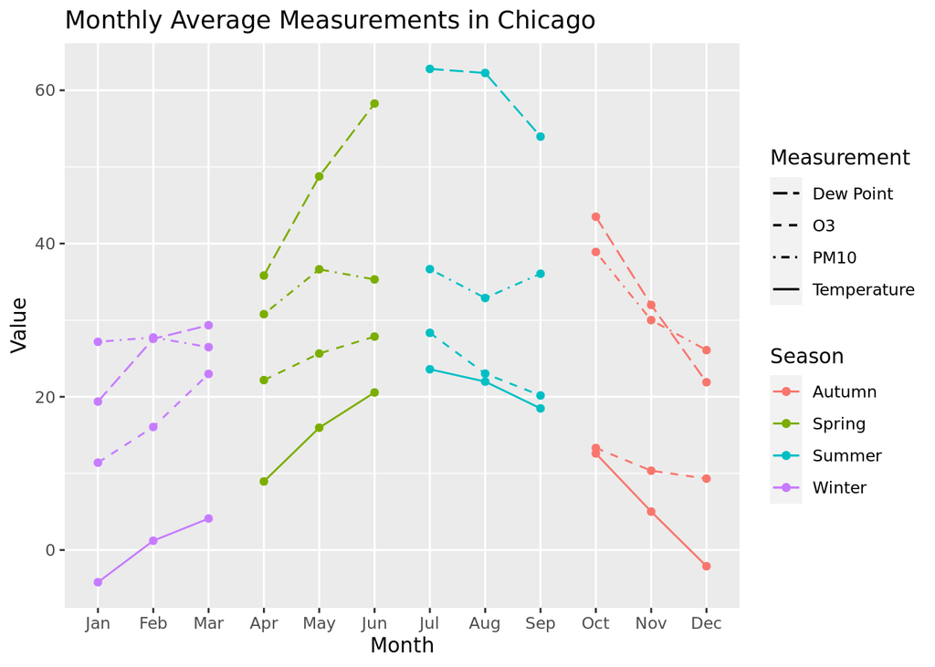

```r
nnmaps_summary <- nnmaps %>%
    mutate(
        date = as.POSIXct(date, format = "%Y-%m-%d")
    ) %>%
    group_by(month, season) %>%
    summarise(
        avg_tempC = mean(tempC, na.rm = TRUE),
        avg_O3 = mean(o3, na.rm = TRUE),
        avg_PM10 = mean(pm10, na.rm = TRUE),
        avg_dewpoint = mean(dewpoint, na.rm = TRUE)
    )
# Plot
library(ggplot2)
library(dplyr)

ggplot(nnmaps_summary) +
    geom_point(aes(x = month, y = avg_tempC, color = season)) +
    geom_line(aes(x = month, y = avg_tempC, color = season, group = season, linetype = "Temperature")) +
    geom_point(aes(x = month, y = avg_O3, color = season)) +
    geom_line(aes(x = month, y = avg_O3, color = season, group = season, linetype = "O3")) +
    geom_point(aes(x = month, y = avg_PM10, color = season)) +
    geom_line(aes(x = month, y = avg_PM10, color = season, group = season, linetype = "PM10")) +
    geom_point(aes(x = month, y = avg_dewpoint, color = season)) +
    geom_line(aes(x = month, y = avg_dewpoint, color = season, group = season, linetype = "Dew Point")) +
    labs(
        x = "Month",
        y = "Value",
        title = "Monthly Average Measurements in Chicago",
        color = "Season",
        linetype = "Measurement"
    ) +
    scale_linetype_manual(values = c("Temperature" = "solid", "O3" = "dashed", "PM10" = "dotdash", "Dew Point" = "longdash"))
```

## Problem 2 - OOP Programming

Create a class to represent a polynomial expression (such as $7x^3 - 3x + 2$) called `poly`. Do this using S4.

1. For the `poly` class, define the following:
- A constructor
- A validator
- A `show` method
- Addition and substraction

```r
# Define the class
setClass(
    "poly",
    slots = list(
        coefficients = "numeric",
        exponents = "numeric"
        )
    )

setMethod(
    "initialize",
    "poly",
    function(.Object, expression = NA, coefficients = numeric(0), exponents = numeric(0)) {
        if (!is.na(expression) && is.character(expression)) {
            # Evaluate the expression
            terms <- unlist(strsplit(expression, split = "(?<=\\D)(?=[+-])|(?<=[+-])(?=\\D)", perl = TRUE))
            coefficients <- numeric()
            exponents <- numeric()
            current_sign <- 1
            for (term in terms) {
                if (term %in% c("+", "-")) {
                    current_sign <- ifelse(term == "+", 1, -1)
                } else if (nzchar(term)) {
                    term <- gsub("\\s+", "", term) # Ignore spaces

                    # When coefficient is 1 or -1, the coefficient part is omitted
                    if (grepl("x", term) && !grepl("\\^", term)) {
                        coef <- ifelse(grepl("x", term) && nchar(gsub("x", "", term)) == 0, current_sign, current_sign * as.numeric(gsub("x", "", term)))
                        exp <- 1
                    } else {
                        parts <- strsplit(term, split = "x\\^")[[1]]
                        coef <- ifelse(length(parts[1]) == 0, current_sign, current_sign * as.numeric(parts[1]))
                        exp <- ifelse(length(parts) == 2, as.numeric(parts[2]), 0)
                    }

                    coefficients <- c(coefficients, coef)
                    exponents <- c(exponents, exp)
                }
            }
        } else {
            if (length(coefficients) != length(exponents)) {
                stop("coefficients and exponents must be of the same length")
            }
            if (any(is.na(coefficients)) || any(is.na(exponents))) {
                stop("coefficients and exponents must not contain NA values")
            }
        }

        .Object@coefficients <- coefficients
        .Object@exponents <- exponents

        validObject(.Object)
        return(.Object)
    }
)

make_poly <- function(expression) {
    new("poly", expression = expression)
}

# Define the validator
setValidity("poly", function(object) {
    # Check that the coefficients and exponents are the same length
    if (length(object@coefficients) != length(object@exponents))
        return("Length of coefficients and exponents must be the same.")
    # Check that the exponents are non-negative integers
    if (any(object@exponents < 0) || any(object@exponents != as.integer(object@exponents)))
        return("Exponents must be non-negative integers.")
    # Check that the coefficients are numeric
    if (!is.numeric(object@coefficients))
        return("Coefficients must be numeric.")
    TRUE
})
```

```
Class "poly" [in ".GlobalEnv"]

Slots:

Name:  coefficients    exponents
Class:      numeric      numeric
```

```r
# Define the show method
setMethod("show", "poly", function(object) {
    terms <- character()
    for (i in seq_along(object@coefficients)) {
        coef <- object@coefficients[i]
        exp <- object@exponents[i]

        if (coef == 0) next
        else if (exp == 0) term <- as.character(coef)
        else if (exp == 1) term <- ifelse(coef == 1, "x", ifelse(coef == -1, "-x", paste0(coef, "x")))
        else term <- ifelse(coef == 1, paste0("x^", exp),
                            ifelse(coef == -1, paste0("-x^", exp), paste0(coef, "x^", exp)))
        terms <- c(terms, term)
    }

    # Combine the terms into a single string
    poly_str <- terms[1]
    for (i in 2:length(terms)) {
        # Add sign according to the coefficient
        if (startsWith(terms[i], "-")) {
            poly_str <- paste(poly_str, "-", substr(terms[i], 2, nchar(terms[i])))
        } else {
            poly_str <- paste(poly_str, "+", terms[i])
        }
    }

    cat(poly_str, "\n")
})

# Define the addition method
setMethod("+", signature(e1 = "poly", e2 = "poly"), function(e1, e2) {
    # Combine exponents and coefficients
    combined <- rbind(
        cbind(e1@coefficients, e1@exponents),
        cbind(e2@coefficients, e2@exponents)
    )
    # Order by exponents
    combined <- combined[order(combined[, 2], decreasing = TRUE), ]
    # Aggregate coefficients by exponents
    result <- aggregate(combined[, 1], list(combined[, 2]), sum)
    # Create a new poly object and show it
    new("poly", coefficients = rev(result$x), exponents = rev(result$Group.1))
})


# Define the substraction method
setMethod("-", signature(e1 = "poly", e2 = "poly"), function(e1, e2) {
    # Combine exponents and coefficients, take negative of the coefficients of e2
    combined <- rbind(
        cbind(e1@coefficients, e1@exponents),
        cbind(-e2@coefficients, e2@exponents)
    )
    # Order by exponents
    combined <- combined[order(combined[, 2], decreasing = TRUE), ]
    # Aggregate coefficients by exponents
    result <- aggregate(combined[, 1], list(combined[, 2]), sum)
    # Create a new poly object and show it
    new("poly", coefficients = rev(result$x), exponents = rev(result$Group.1))
})
```

2. Use your `poly` class to run the following code:

```r
p1 <- make_poly("3x^2 + 2")
p2 <- make_poly("7x^3 - 2x^2 - x + 17")
p1
```

```
3x^2 + 2
```

```r
p2
```

```
7x^3 - 2x^2 - x + 17
```

```r
p1 + p2
```

```
7x^3 + x^2 - x + 19
```

```r
p1 - p2
```

```
-7x^3 + 5x^2 + x - 15
```

## Problem 3 - Tidyverse

Use the `tidyverse` for this problem. In particular, use piping and `dplyr` as much as you are able. **Note:** Use of any deprecated functions will result in a point loss.

Install and load the package `nycflights13`.

**a. Generate a table (which can just be a nicely printed tibble) reporting the mean and median departure delay per airport. Generate a second table (which again can be a nicely printed tibble) reporting the mean and median arrival delay per airport. Exclude any destination with under 10 flights. Do this exclusion through code, not manually.**

**Additionally,**

- Order both tables in descending mean delay.
- Both tables should use the airport names not the airport codes.
- Both tables should print all rows.

```r
library(nycflights13)
library(data.table)
# Convert flights and airports to data.table
flights_dt <- as.data.table(flights)
airports_dt <- as.data.table(airports)

# Filter out airports with less than 10 flights
valid_origins <- flights_dt[, .N, by = .(origin)][N >= 10, origin]
filtered_flights <- flights_dt[origin %in% valid_origins]

dep_delay_table <- filtered_flights[, .(mean_dep_delay = mean(dep_delay, na.rm = TRUE),
                                        median_dep_delay = median(dep_delay, na.rm = TRUE)
                                    ), by = .(origin)]
# Add airport names
dep_delay_table <- airports_dt[dep_delay_table, on = .(faa = origin),
                                .(name, mean_dep_delay, median_dep_delay)]
# Order by mean departure delay
dep_delay_table <- dep_delay_table[order(-mean_dep_delay)]
dep_delay_table
```

```
                  name mean_dep_delay median_dep_delay
1: Newark Liberty Intl       15.10795               -1
2: John F Kennedy Intl       12.11216               -1
3:          La Guardia       10.34688               -3
```

```r
# Similar steps for the arrival delay table
arr_delay_table <- filtered_flights[, .(mean_arr_delay = mean(arr_delay, na.rm = TRUE),
                                        median_arr_delay = median(arr_delay, na.rm = TRUE)
                                    ), by = .(dest)]
# Add airport names
arr_delay_table <- airports_dt[arr_delay_table, on = .(faa = dest),
                                .(name, mean_arr_delay, median_arr_delay)]
# Order by mean arrival delay
arr_delay_table <- arr_delay_table[order(-mean_arr_delay)]
arr_delay_table
```

```
                          name mean_arr_delay median_arr_delay
  1:     Columbia Metropolitan      41.764151             28.0
  2:                Tulsa Intl      33.659864             14.0
  3:         Will Rogers World      30.619048             16.0
  4:      Jackson Hole Airport      28.095238             15.0
  5:             Mc Ghee Tyson      24.069204              2.0
 ---
101:                      <NA>      -3.835907             -9.0
102: John Wayne Arpt Orange Co      -7.868227            -11.0
103:         Palm Springs Intl     -12.722222            -13.5
104:                Blue Grass     -22.000000            -22.0
105:                La Guardia            NaN               NA
```

**b. How many flights did the aircraft model with the fastest average speed take? Produce a tibble with 1 row, and entires for the model, average speed (in MPH) and number of flights.**

```r
planes_dt <- as.data.table(planes)
# Join flights and planes
flights_planes_dt <- flights_dt[planes_dt, on = .(tailnum)]

# Calculate average speed and number of flights for each model
result_dt <- flights_planes_dt[, .(avg_speed = mean(speed, na.rm = TRUE), num_flights = .N), by = .(model)]
result_dt <- result_dt[!is.na(avg_speed) & num_flights > 0]

# Order by average speed
fastest_model_dt <- result_dt[order(-avg_speed)][1]

print(fastest_model_dt)
```

```
     model avg_speed num_flights
1: DC-9-51       432          91
```